# Modeling Index Returns with Hidden Markov Model using SGH Distribution

Stephen

October 2014

## Getting the Data

Before getting the stock data we specify some stock indices to be used.

```
##      symbols  symbols.names
## [1,] "^FTSE"  "FTSE 100"
## [2,] "^GDAXI" "DAX"
## [3,] "^FCHI"  "CAC 40"
## [4,] "^GSPC"  "S&P 500"
## [5,] "^N225"  "Nikkei 225"
## [6,] "^HSI"   "Hang Seng"
## [7,] "^BVSP"  "Bovespa"
## [8,] "^MXX"   "IPC"
```

```r
# returns list: [[1]] data frame of given series from all symbols
# [[2]] full list of all series from all symbols
multiStockHistory <- function(symbols, #char vector
                              symbols.names, #char vector
                              startday=1, #int
                              startmonth=1,
                              startyear=1970,
                              endday=19,
                              endmonth=10,
                              endyear=2014,
                              series="Adj.Close",
                              ...)
  {
  #if(!require(xts)) {install.packages('xts')}
  if(is.null(symbols.names)) {symbols.names <- symbols}

  # loop through symbols downloading series to list
  x <- list()
  for (i in 1:length(symbols)) {
    base <- "http://ichart.yahoo.com/table.csv?s="
    tail <- paste("&a=",startday,"&b=",startmonth,"&c=",startyear,"&d=",endday,"&e=",endmonth,"&f=",endyear,"&g=d&ignore=.csv",sep="")
    url <- paste(base,symbols[i],tail,sep="")
    x[[i]] <- read.table(url,sep=",",header=T, stringsAsFactors=F,flush = T,...)
    x[[i]][,1] <- as.Date(x[[i]][,1])
    x[[i]] <- xts(x[[i]][,-1], order.by=x[[i]][,1])
    xtsAttributes(x[[i]]) <- list(IndexSymbol=symbols[i], IndexName=symbols.names[i])
    if(i%%2 == 0) {cat("pulled symbol ",i,"\n") }
  }

  #build xts df with only 1 series, e.g., Adj.Close
  ind.df <- data.frame()
  for (i in 1:length(x)) {
    if (dim(ind.df)[2]==0) {
      ind.df <- x[[i]][,series]
      colnames(ind.df)[i] <- unlist(xtsAttributes(x[[i]]))[2]
    } else {
    ind.df <- merge.xts(ind.df,x[[i]][,series])
    colnames(ind.df)[i] <- unlist(xtsAttributes(x[[i]]))[2]
    }
  }
  return(list(df=ind.df,full.list=x))
} #end function
y <- multiStockHistory(symbols = symbols,symbols.names = symbols.names,
                       startday=1,startmonth=1,startyear=1999,
                       endday=19,endmonth=10,endyear=2014,series="Adj.Close")
dput(x = y, file = "historicalIndicesList.Rdata")
```

```r
y <- dget("historicalIndicesList.Rdata")
ydf <- y$df
ydfn <- na.omit(ydf)
head(ydfn)
```

```
##            FTSE.100  DAX CAC.40 S.P.500 Nikkei.225 Hang.Seng Bovespa  IPC
## 1999-02-01     6012 5191   4304    1273      14465      9600    8891 4030
## 1999-02-02     6013 5167   4244    1262      14350      9503    8732 4015
## 1999-02-03     5940 5086   4189    1272      14161      9420    8676 4061
## 1999-02-04     5940 5078   4167    1248      14087      9439    8653 4014
## 1999-02-08     5835 5027   4154    1244      13992      9140    8824 4017
## 1999-02-09     5780 4904   4038    1216      13903      9244    8674 3947
```

```r
summary(ydfn)
```

```
##      Index               FTSE.100         DAX            CAC.40
##  Min.   :1999-02-01   Min.   :3287   Min.   : 2203   Min.   :2403
##  1st Qu.:2003-02-04   1st Qu.:4987   1st Qu.: 4821   1st Qu.:3564
##  Median :2007-01-04   Median :5701   Median : 5955   Median :4068
##  Mean   :2006-12-28   Mean   :5539   Mean   : 5978   Mean   :4258
##  3rd Qu.:2010-11-30   3rd Qu.:6239   3rd Qu.: 7085   3rd Qu.:4852
##  Max.   :2014-10-17   Max.   :6930   Max.   :10029   Max.   :6857
##     S.P.500       Nikkei.225      Hang.Seng        Bovespa
##  Min.   : 676   Min.   : 7055   Min.   : 8409   Min.   : 8371
##  1st Qu.:1115   1st Qu.: 9801   1st Qu.:13180   1st Qu.:16396
##  Median :1267   Median :11582   Median :17177   Median :39128
##  Mean   :1277   Mean   :12521   Mean   :17346   Mean   :38363
##  3rd Qu.:1408   3rd Qu.:15301   3rd Qu.:21740   3rd Qu.:57252
##  Max.   :2011   Max.   :20833   Max.   :31638   Max.   :73517
##       IPC
##  Min.   : 3941
##  1st Qu.: 7178
##  Median :20917
##  Mean   :21999
##  3rd Qu.:34389
##  Max.   :46357
```

```r
dim(ydfn)
```

```
## [1] 3398    8
```

Next we need exchange rates to standardize indices to a single currency, in this case US$. Exchange rates can be downloaded from the US Federal Reserve at *www.federalreserve.gov/datadownload/* to choose which currencies. The file used in this analysis was pulled from: http://www.federalreserve.gov/datadownload/Download.aspx?rel=H10&series=a6a0113179fdeb9c6fbcdc18575ec09c&filetype=csv&label=include&layout=seriescolumn&from=01/01/1999&to=04/09/2014

```r
# exchange rates from 01-01-1999 to 04-09-2014
url <- "http://www.federalreserve.gov/datadownload/Output.aspx?rel=H10&series=a6a0113179fdeb9c6fbcdc18575ec09c&lastObs=&from=01/01/1999&to=04/09/2014&filetype=csv&label=include&layout=seriescolumn"
ex <- read.table(url,skip=5,sep=",",na.strings="ND",header=T,stringsAsFactors = F)
ex[,1] <- ymd(ex[,1])
ex <- as.xts(ex[,-1], order.by=ex[,1])
# assign colnames from two-letter currency code (last 2 digits)
for (i in 1:length(names(ex))) {
  colnames(ex)[i] <- substr(colnames(ex)[i],nchar(colnames(ex)[i])-1,nchar(colnames(ex)[i]))
}
ex <- na.omit(ex)
# drop the returns dates outside of exchange dates range
exsub <- ex["1999/2014-04-04"]
ydfsub <- ydf["1999/2014-04-04"]
```

Merge the returns series with the exchange rate data and and convert all series to US$.

```r
merged <- na.omit(merge.xts(ydfsub,exsub))

# data frame for converted returns
r <- merged[,1:8]
# [1] "FTSE.100"   "DAX"        "CAC.40"
# [4] "S.P.500"    "Nikkei.225" "Hang.Seng"
# [7] "Bovespa"    "IPC"
r[,1] <- merged[,1] *  merged$UK
r[,2] <- merged[,2] *  merged$EU
r[,3] <- merged[,3] *  merged$EU
r[,4] <- merged[,4] *  1
r[,5] <- merged[,5] /  merged$JA
r[,6] <- merged[,6] /  merged$HK
r[,7] <- merged[,7] /  merged$BZ
r[,8] <- merged[,8] /  merged$MX
head(r)
```

```
##            FTSE.100  DAX CAC.40 S.P.500 Nikkei.225 Hang.Seng Bovespa   IPC
## 1999-02-01     9866 5867   4865    1273      125.7      1239    4513 398.2
## 1999-02-02     9879 5853   4807    1262      128.0      1226    4824 397.7
## 1999-02-03     9727 5767   4750    1272      125.9      1216    4820 401.0
## 1999-02-04     9738 5741   4712    1248      125.7      1218    4741 396.8
## 1999-02-08     9558 5679   4692    1244      122.3      1179    4669 398.0
## 1999-02-09     9453 5542   4563    1216      121.5      1193    4541 391.6
```

```r
summary(r)
```

```
##      Index               FTSE.100          DAX            CAC.40
##  Min.   :1999-02-01   Min.   : 4873   Min.   : 2428   Min.   :2621
##  1st Qu.:2002-12-04   1st Qu.: 7973   1st Qu.: 5376   1st Qu.:4341
##  Median :2006-09-17   Median : 9202   Median : 6997   Median :5014
##  Mean   :2006-09-17   Mean   : 9158   Mean   : 7241   Mean   :5155
##  3rd Qu.:2010-07-06   3rd Qu.:10170   3rd Qu.: 9186   3rd Qu.:5776
##  Max.   :2014-04-04   Max.   :13965   Max.   :13381   Max.   :8462
##     S.P.500       Nikkei.225      Hang.Seng       Bovespa
##  Min.   : 676   Min.   : 63.2   Min.   :1078   Min.   : 2157
##  1st Qu.:1110   1st Qu.:102.7   1st Qu.:1682   1st Qu.: 7158
##  Median :1260   Median :115.8   Median :2160   Median :17092
##  Mean   :1253   Mean   :118.6   Mean   :2200   Mean   :19117
##  3rd Qu.:1394   3rd Qu.:138.0   3rd Qu.:2752   3rd Qu.:30033
##  Max.   :1891   Max.   :198.0   Max.   :4083   Max.   :44667
##       IPC
##  Min.   : 392
##  1st Qu.: 721
##  Median :1743
##  Mean   :1794
##  3rd Qu.:2771
##  Max.   :3680
```

```r
# log differenced data for returns
rna <- na.omit(r)
ret <- diff(rna,lag = 1,log = T)
ret <- na.omit(ret)
```

Lets take a look at these data.

[figure not shown]

```r
xtsExtra::plot.xts(log(ydfsub), screens=factor(1,1), auto.legend=T, legend.loc = "topleft" , main="Selected World Composite Indices \n (log daily prices in USD)", minor.ticks=F,cex=.6)
```

And check their correlations.

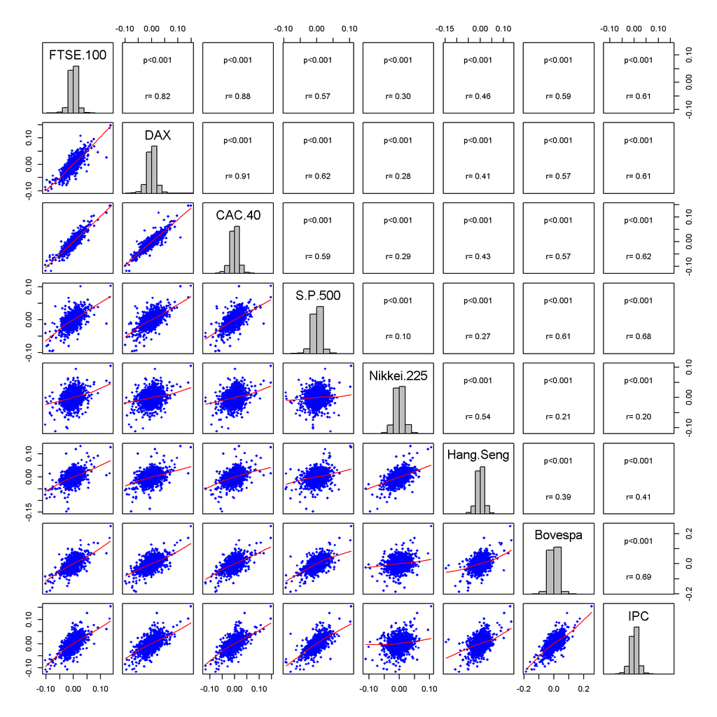

```r
pairs(as.data.frame(ret),
      lower.panel=panel.smooth,upper.panel=panel.cor,diag.panel=panel.hist)
```

## Symmetric Generalized Hyperbolic Distribution

The **ghyp** package offers the ability to fit symmetric generalized hyperbolic (SGH) distributions in **R**. We fit the pairs assuming an SGH and plot.

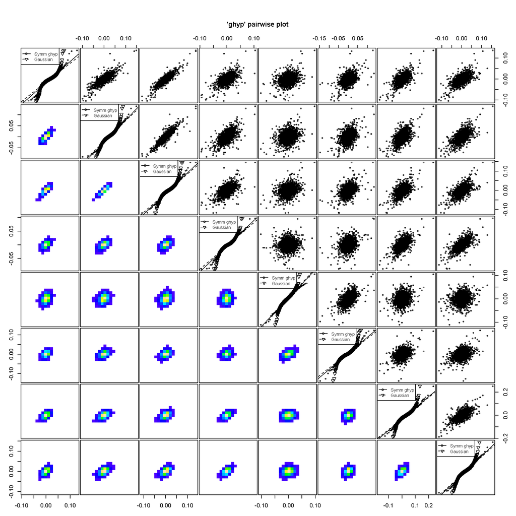

```r
library(ghyp)
ghypmv.fit <- ghyp::fit.ghypmv(data=ret,silent=TRUE, symmetric=T)
pairs(ghypmv.fit, cex=0.5, nbins=20)
```

And we can isolate a few specific series like the S&P500 and DAX.

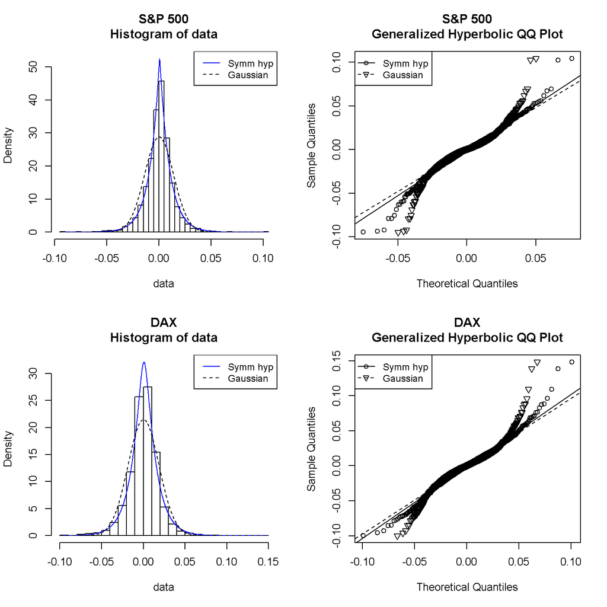

```r
ghypuv.fit.sp <- fit.hypuv(data=ret[,"S.P.500"],silent=T,symmetric=T)
ghypuv.fit.dx <- fit.hypuv(data=ret[,"DAX"],silent=T,symmetric=T)

par(mfrow=c(2,2))
hist(ghypuv.fit.sp,ghyp.col="blue",legend.cex=0.9,
     main="S&P 500\nHistogram of data")
qqghyp(ghypuv.fit.sp,plot.legend=T,legend.cex=0.9,
       main="S&P 500\nGeneralized Hyperbolic QQ Plot")
hist(ghypuv.fit.dx,ghyp.col="blue",legend.cex=0.9,
     main="DAX\nHistogram of data")
qqghyp(ghypuv.fit.dx,plot.legend=T,legend.cex=0.9,
       main="DAX\nGeneralized Hyperbolic QQ Plot")
```

## HMM SGM Algorithm

The `depmix()` function in the **depmixS4** package can get us a HMM fit assuming a Gaussian distribution or several other common distributions, but not generalized hyperbolic. That’s a start. These Markov state classifications combined with the `fit.ghypmv()` function in the **ghyp** package for fitting multivariate SGH should provide an improvement over the HMM assuming Gaussian returns.

The piecemeal algorithm for combining these two packages in **R** is as follows:

1. Compute steady-state Markov transition probabilities by fitting HMM under Gaussian distribution with `depmixS4::depmix()` function
2. Assign Markov states based on Gaussian HMM posterior probabilities from (1)
3. Fit SGH_1_ and SGH_2_ distributions separately for subset of data classified as state 1 or state 2 in previous step with `ghyp::fit.ghypmv(...,symmetric=TRUE)` function
4. Use SGH_i_ parameters and Gaussian HMM transition probabilities to calculate posterior probabilities for each time period

This is performed with the `ghypMarkov()` function defined below:

```r
# returns a list of posterior probabilities, HMM state classifications,
# parameters, transition matrix and steady state probabilities
ghypMarkov <- function(data,
                       response,  #list of series in dataframe
                       family, #list of initial HMM distr used in depmix()
                       ...
                       ) {
  library(depmixS4)
  library(ghyp)

  ## Markov multistep calculation assumes only 2 Markov states #########
  # 1. determine states from Gaussian
  msp <- depmix(data=data, response = response,family = family, nstates = 2, ...)
  #optimize parameters
  set.seed(1)
  fmsp <- fit(msp, ...)

  # 2. fit ghypmv to only obs identified as state 1 (or 2)
  s1 <- which(posterior(fmsp)[,1]==1)
  s2 <- which(posterior(fmsp)[,1]==2)

  fitghs1 <- fit.ghypmv(data = data[s1,],symmetric = T,save.data = T,trace = T,silent = T, ...)

  lambda1 <- attributes(fitghs1)$lambda
  alpha.bar1 <- attributes(fitghs1)$alpha.bar
  mu1 <- attributes(fitghs1)$mu
  sigma1 <- attributes(fitghs1)$sigma
  gamma1 <- rep(0,dim(data)[2])

  fitghs2 <- fit.ghypmv(data = data[s2,],symmetric = T,save.data = T,trace = T,silent = T, ...)

  lambda2 <- attributes(fitghs2)$lambda
  alpha.bar2 <- attributes(fitghs2)$alpha.bar
  mu2 <- attributes(fitghs2)$mu
  sigma2 <- attributes(fitghs2)$sigma
  gamma2 <- rep(0,dim(data)[2])

  # 3. recalculate posterior probabilities with new ghypmv params
  p <- matrix(rep(NA,4),2)
  p[1,1:2] <- attributes(attributes(fmsp)$transition[[1]])$parameters$coefficients
  p[2,1:2]<- attributes(attributes(fmsp)$transition[[2]])$parameters$coefficients

  pi <- vector()
  pi[1] <- (1-p[2,2]) / (2 - p[1,1] - p[2,2])
  pi[2] <- (1-p[1,1]) / (2 - p[1,1] - p[2,2])

  ghyp1 <- ghyp(lambda = lambda1,
                alpha.bar = alpha.bar1,
                mu = mu1,
                sigma = sigma1,
                gamma = gamma1 )
  ghyp2 <- ghyp(lambda = lambda2,
                alpha.bar = alpha.bar2,
                mu = mu2,
                sigma = sigma2,
                gamma = gamma2)
  dgh1 <- dghyp(x = data[s1,], object = ghyp1)
  dgh2 <- dghyp(x = data[s2,], object = ghyp2)

  pstar1 <- c()
  pstar2 <- c()

  for (i in 1:dim(data)[1]) {
    if (i==1) {
      post1 <- (pi[1]*p[1,1]+pi[2]*p[2,1])*dghyp(x=data[1,],
                                                 object=ghyp1)
      post2 <- (pi[1]*p[1,2]+pi[2]*p[2,2])*dghyp(x=data[1,],
                                                 object=ghyp2)
      pstar1[i] <- post1 / (post1 + post2)
      pstar2[i] <- post2 / (post1 + post2)
    } else {
      post1 <- (pstar1[i-1]*p[1,1]
                +pstar2[i-1]*p[2,1])*dghyp(x=data[i-1,],
                                           object=ghyp1)
      post2 <- (pstar1[i-1]*p[1,2]
                +pstar2[i-1]*p[2,2])*dghyp(x=data[i-1,],
                                           object=ghyp2)
      pstar1[i] <- post1 / (post1 + post2)
      pstar2[i] <- post2 / (post1 + post2)
    }
  }
psdf <- data.frame(pstar1=pstar1,pstar2=pstar2)
  psdf$state <- NA
  psdf$state[psdf$pstar2 >= .5] <- 2
  psdf$state[psdf$pstar1 >= .5] <- 1
  psdf <- psdf[,c(3,1,2)]  #reorder state var first

  return(list(ghyp.posterior=psdf,
              ghyp.state1=fitghs1,
              ghyp.state2=fitghs2,
              gaussian.posterior=posterior(fmsp),
              pi=pi,
              p=p) )
} # end function
```

To run the `ghypMarkov()` function we first need to assign the response series as a list according to the `depmix()` convention, and then define the family of distributions for each series to be used by `depmix()` as well.

```r
library(depmixS4)
library(ghyp)

# run functions
response8 <- list(FTSE.100~1,DAX~1,CAC.40~1,S.P.500~1,Nikkei.225~1,
                  Hang.Seng~1,Bovespa~1,IPC~1)
family8 <- list(gaussian(),gaussian(),gaussian(),gaussian(),
                gaussian(),gaussian(),gaussian(),gaussian())

# 8 indices
fit.ghypMarkov <- ghypMarkov(data = ret,
                             response = response8,
                             family = family8)
```

```
## iteration 0 logLik: 68382
## iteration 5 logLik: 72595
## iteration 10 logLik: 72605
## iteration 15 logLik: 72605
## iteration 20 logLik: 72605
## iteration 25 logLik: 72605
## iteration 30 logLik: 72605
## iteration 35 logLik: 72605
## converged at iteration 36 with logLik: 72605
```

The parameters for the different states are now easily extracted from the resulting list:

```r
fit.ghypMarkov$ghyp.state1
```

```
## Symmetric Generalized Hyperbolic Distribution:
##
## Parameters:
##     lambda  alpha.bar
## -3.158e+00  2.898e-07
##
## mu:
## [1] -0.005207 -0.006357 -0.006535 -0.003614 -0.003290 -0.004208 -0.007474
## [8] -0.005371
##
## sigma:
##             FTSE.100       DAX    CAC.40   S.P.500 Nikkei.225 Hang.Seng
## FTSE.100   0.0007345 0.0008027 0.0008261 4.456e-04  2.160e-04 0.0003905
## DAX        0.0008027 0.0011225 0.0010499 5.765e-04  2.443e-04 0.0004203
## CAC.40     0.0008261 0.0010499 0.0010877 5.497e-04  2.571e-04 0.0004368
## S.P.500    0.0004456 0.0005765 0.0005497 5.997e-04  6.588e-05 0.0001930
## Nikkei.225 0.0002160 0.0002443 0.0002571 6.588e-05  5.780e-04 0.0004018
## Hang.Seng  0.0003905 0.0004203 0.0004368 1.930e-04  4.018e-04 0.0007299
## Bovespa    0.0008176 0.0009738 0.0009601 7.603e-04  2.618e-04 0.0005297
## IPC        0.0006176 0.0007533 0.0007502 6.081e-04  1.841e-04 0.0003946
##              Bovespa       IPC
## FTSE.100   0.0008176 0.0006176
## DAX        0.0009738 0.0007533
## CAC.40     0.0009601 0.0007502
## S.P.500    0.0007603 0.0006081
## Nikkei.225 0.0002618 0.0001841
## Hang.Seng  0.0005297 0.0003946
## Bovespa    0.0018915 0.0010959
## IPC        0.0010959 0.0010377
##
## gamma:
## [1] 0 0 0 0 0 0 0 0
##
## log-likelihood:
## 18160
##
##
## Call:
## fit.ghypmv(data = data[s1, ], symmetric = T, silent = T, save.data = T,     trace = T)
```

```r
fit.ghypMarkov$ghyp.state2
```

```
## Symmetric Generalized Hyperbolic Distribution:
##
## Parameters:
##    lambda alpha.bar
##  4.259670  0.004611
##
## mu:
## [1] 0.001419 0.002020 0.001749 0.001007 0.001143 0.001494 0.002462 0.002105
##
## sigma:
##             FTSE.100       DAX    CAC.40   S.P.500 Nikkei.225 Hang.Seng
## FTSE.100   7.347e-05 6.307e-05 6.496e-05 2.266e-05  1.883e-05 2.374e-05
## DAX        6.307e-05 1.122e-04 9.361e-05 3.304e-05  2.583e-05 2.674e-05
## CAC.40     6.496e-05 9.361e-05 1.053e-04 2.976e-05  2.341e-05 2.626e-05
## S.P.500    2.266e-05 3.304e-05 2.976e-05 6.198e-05  1.288e-06 5.358e-06
## Nikkei.225 1.883e-05 2.583e-05 2.341e-05 1.288e-06  1.812e-04 6.614e-05
## Hang.Seng  2.374e-05 2.674e-05 2.626e-05 5.358e-06  6.614e-05 1.305e-04
## Bovespa    4.834e-05 6.008e-05 6.006e-05 5.802e-05  1.577e-05 3.096e-05
## IPC        3.653e-05 4.734e-05 4.614e-05 4.647e-05  1.278e-05 2.358e-05
##              Bovespa       IPC
## FTSE.100   4.834e-05 3.653e-05
## DAX        6.008e-05 4.734e-05
## CAC.40     6.006e-05 4.614e-05
## S.P.500    5.802e-05 4.647e-05
## Nikkei.225 1.577e-05 1.278e-05
## Hang.Seng  3.096e-05 2.358e-05
## Bovespa    3.142e-04 1.035e-04
## IPC        1.035e-04 1.385e-04
##
## gamma:
## [1] 0 0 0 0 0 0 0 0
##
## log-likelihood:
## 63467
##
##
## Call:
## fit.ghypmv(data = data[s2, ], symmetric = T, silent = T, save.data = T,     trace = T)
```

[figure not shown]

```r
filSGH10 <- filter(fit.ghypMarkov[[1]][,2],filter = rep(1/10,10),
                 method = "convolution",sides = 1)
filGaus10 <- filter(fit.ghypMarkov[[4]][,2],filter = rep(1/10,10),
              method = "convolution",sides = 1)
filSGH100 <- filter(fit.ghypMarkov[[1]][,2],filter = rep(1/100,100),
                 method = "convolution",sides = 1)
filGaus100 <- filter(fit.ghypMarkov[[4]][,2],filter = rep(1/100,100),
              method = "convolution",sides = 1)
par(mfrow=c(2,1))
par(mar=c(2,4.3,2.1,1.5))

matplot(cbind(fit.ghypMarkov[[1]][,2],
              fit.ghypMarkov[[4]][,2],
              filSGH100,
              filGaus100),
        alpha=0.5,
        type="l",ylab=expression(P(xi[1])),
        main="Gaussian vs SGH Markov Posterior Probabilities",
        lty=c(1,1,1,1),lwd=c(1,1,3,3)
        )
matplot(cbind(fit.ghypMarkov[[1]][,2],
              fit.ghypMarkov[[4]][,2],
              filSGH10,
              filGaus10),
        type="l",xlim=c(2300,2400),
        main="Zoom into 100pd Window",
        ylab=expression(P(xi[i1])),lty=c(1,1,1,1), lwd=c(1,1,2,2)
        )

legend(x=2370,y=.8,legend=c("SGH","Gaussian","SGH-10pdMA","Gaus-10pdMA"),
       col=c('black','red','green','blue'),
       lty=c(1,1,1,1),lwd=c(1,1,2,2))
```

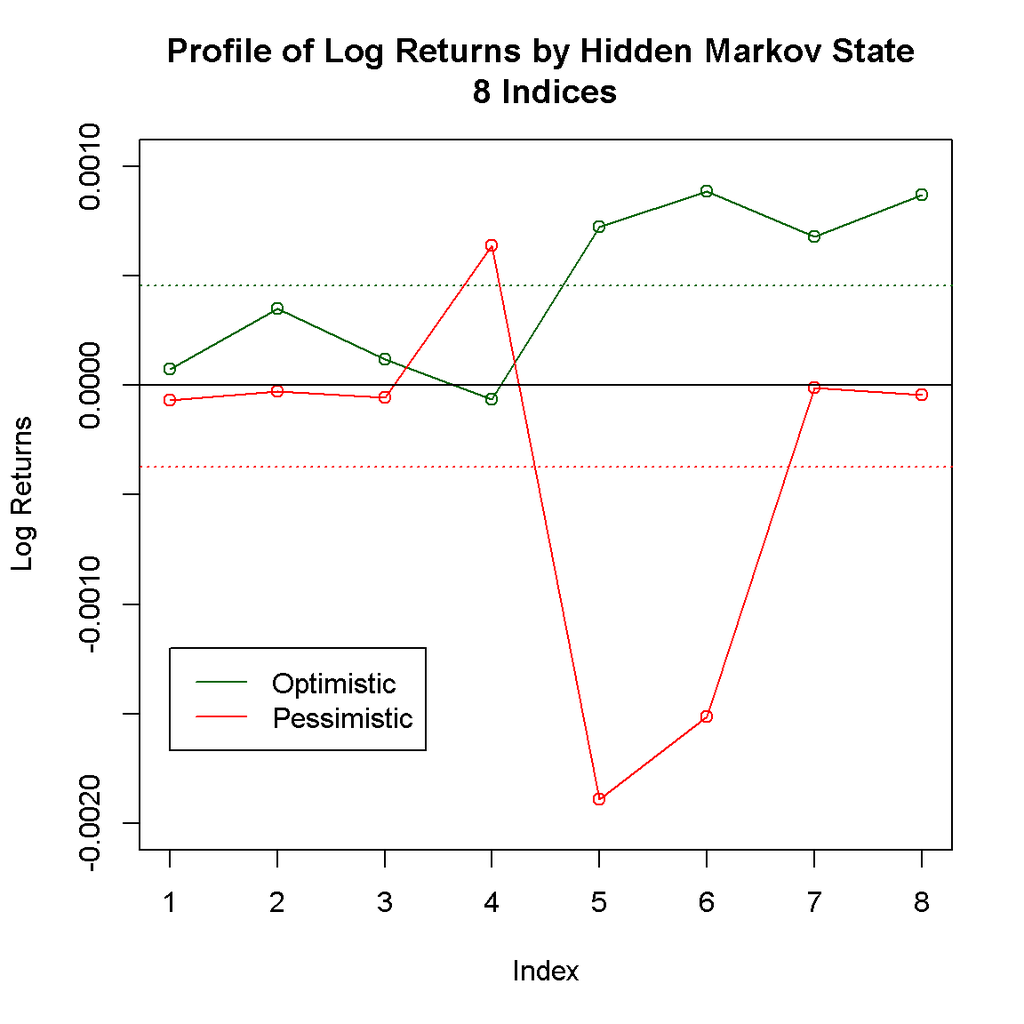

```r
retMarkov <- function(data,
                      posterior)
  {
  #returns by hidden state
  mret <- data.frame(state1=rep(NA,dim(data)[2]),state2=rep(NA,dim(data)[2]))
  for (i in 1:dim(data)[2]) {
    mret[i,1] <- mean(data[posterior[,1]==1,i])
    mret[i,2] <- mean(data[posterior[,1]==2,i])
  }
  row.names(mret) <- names(data)

  mrettot <- data.frame(state1=rep(NA,1),state2=rep(NA,1))
  mrettot[1,1] <- mean(data[posterior[,1]==1,])
  mrettot[1,2] <- mean(data[posterior[,1]==2,])

  if(mrettot[1,1]>mrettot[1,2]) {
    colnames(mret) <- c("Optimistic", "Pessimistic")
    colnames(mrettot) <- c("Optimistic", "Pessimistic")
  } else {
    colnames(mret) <- c("Pessimistic", "Optimistic")
    colnames(mrettot) <- c("Pessimistic", "Optimistic")
  }

  return(list(returns.by.index=mret, returns.total=mrettot))
} #end function

ret8 <- retMarkov(data = ret, posterior = fit.ghypMarkov[[1]])

plot(ret8$returns.by.index$Optimistic,type='o',col='dark green',ylim=c(-.002,.001),main="Profile of Log Returns by Hidden Markov State \n8 Indices",ylab="Log Returns");lines(ret8$returns.by.index$Pessimistic,type='o',col='red');abline(h = 0);abline(h=ret8$returns.total$Optimistic,lty=3,col='dark green');abline(h=ret8$returns.total$Pessimistic,lty=3,col='red');legend(x = 1,y = -.0012,legend = c("Optimistic","Pessimistic"),lty = 1,col = c('dark green','red'))
```

## References

1. Breymann, W. and Luthi, D. (2013) [ghyp: A package on generalized hyperbolic distributions](http://cran.r-project.org/web/packages/ghyp/vignettes/Generalized_Hyperbolic_Distribution.pdf)
2. Visser, I. and Speekenbrink, M. (2014) [depmixS4: An R Package for Hidden Markov Models](http://www.jstatsoft.org/v36/i07/paper)